# Homework #2

Chase Weida; Github: cweida

2/5/2020

0. What is the smallest positive odd integer? Storage it in a variable named a0 and print it.

```r
a0 <- 1
a0
```

```
## [1] 1
```

1. Today’s temperature has a high of 24 and a low of 15 degree fahrenheit. Find the corresponding degress in celsius and storage it in a (single) vector named cel. Print the variable.

```r
high <- 24
low <- 15
highc <- (high-32)*(5/9)
lowc <- (low-32)*(5/9)
cel <- c(highc, lowc)
cel
```

```
## [1] -4.444444 -9.444444
```

2. Create a vector of length 200. The odd entries should be 3 and even entries should be 1. Storage the created in a variable named vec200 and print.

```r
vec200 <- rep(1,200)
n <- length(vec200)
vec200[seq(1,n,2)] <- 3
vec200
```

```
##   [1] 3 1 3 1 3 1 3 1 3 1 3 1 3 1 3 1 3 1 3 1 3 1 3 1 3 1 3 1 3 1 3 1 3 1 3 1 3
##  [38] 1 3 1 3 1 3 1 3 1 3 1 3 1 3 1 3 1 3 1 3 1 3 1 3 1 3 1 3 1 3 1 3 1 3 1 3 1
##  [75] 3 1 3 1 3 1 3 1 3 1 3 1 3 1 3 1 3 1 3 1 3 1 3 1 3 1 3 1 3 1 3 1 3 1 3 1 3
## [112] 1 3 1 3 1 3 1 3 1 3 1 3 1 3 1 3 1 3 1 3 1 3 1 3 1 3 1 3 1 3 1 3 1 3 1 3 1
## [149] 3 1 3 1 3 1 3 1 3 1 3 1 3 1 3 1 3 1 3 1 3 1 3 1 3 1 3 1 3 1 3 1 3 1 3 1 3
## [186] 1 3 1 3 1 3 1 3 1 3 1 3 1 3 1
```

3. How many perfect squares are there between 1 and 2001? Storage the answer in a variable named numPerfect and print.

```r
n <- seq(1,2001,1)
n <- sqrt(n)
n <- round(n, 3)

numPerfect <- length(n[!n%%1])
numPerfect
```

```
## [1] 44
```

### Cars and Mileage

1. What are the 3 most fuel-efficient models in terms of highway mileage? Storage the data frame (with 3 rows) containing all information of these three cars in a variable named top3 and print.

```r
mpg
```

```
## # A tibble: 234 x 11
##    manufacturer model    displ  year   cyl trans   drv     cty   hwy fl    class
##    <chr>        <chr>    <dbl> <int> <int> <chr>   <chr> <int> <int> <chr> <chr>
##  1 audi         a4         1.8  1999     4 auto(l… f        18    29 p     comp…
##  2 audi         a4         1.8  1999     4 manual… f        21    29 p     comp…
##  3 audi         a4         2    2008     4 manual… f        20    31 p     comp…
##  4 audi         a4         2    2008     4 auto(a… f        21    30 p     comp…
##  5 audi         a4         2.8  1999     6 auto(l… f        16    26 p     comp…
##  6 audi         a4         2.8  1999     6 manual… f        18    26 p     comp…
##  7 audi         a4         3.1  2008     6 auto(a… f        18    27 p     comp…
##  8 audi         a4 quat…   1.8  1999     4 manual… 4        18    26 p     comp…
##  9 audi         a4 quat…   1.8  1999     4 auto(l… 4        16    25 p     comp…
## 10 audi         a4 quat…   2    2008     4 manual… 4        20    28 p     comp…
## # … with 224 more rows
```

```r
mpgOrder <- mpg[order(-mpg$hwy),]
top3 <- mpgOrder[1:3,]
top3
```

```
## # A tibble: 3 x 11
##   manufacturer model   displ  year   cyl trans   drv     cty   hwy fl    class
##   <chr>        <chr>   <dbl> <int> <int> <chr>   <chr> <int> <int> <chr> <chr>
## 1 volkswagen   jetta     1.9  1999     4 manual… f        33    44 d     compact
## 2 volkswagen   new be…   1.9  1999     4 manual… f        35    44 d     subcom…
## 3 volkswagen   new be…   1.9  1999     4 auto(l… f        29    41 d     subcom…
```

##### Analysis:

We may very quickly find the top 3 performing cars in terms of highway mileage by ordering the entire dataframe by the “hwy” column. The order function works very well to this end. We can see that the top three performing cars are all Volkswagen brand. The number one is the Jetta with 44 mpg on the highway. Oddly enough, the three highest performing cars are from 1999 as opposed to a newer year.

2. How many different compact models are included in this dataset? Storage the answer in a variable named numCompact and print.

```r
numCompact <- sum(mpg$class =='compact')
numCompact
```

```
## [1] 47
```

##### Analysis:

Finding the number of specifically compact cars is very easy in R. First we convert the entire “class” column to booleans depending on whether the class of the car is compact or not. Then we sum the entire column of boolean results. Trues are treated as 1 and Falses are zeroes. Hence, the sum is our number of cars which are compact. The mpg dataframe has a total of 234 rows. Thus, just over 20% of the cars represented in the mpg dataframe are compact cars.

3. Create a scatterplot of hwy and cty and describe the relationship. Why are there so few points visible? Explain your findings.

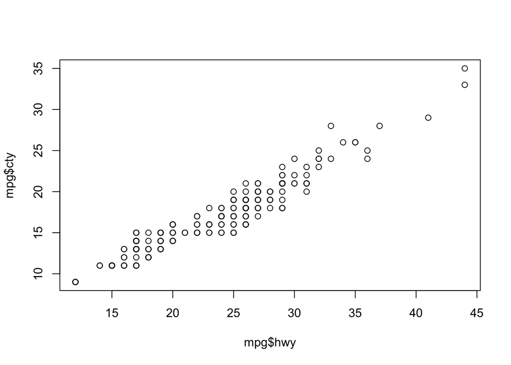

```r
plot(mpg$hwy,mpg$cty)
```

##### Analysis:

Visually, one may easily observe a strong linear relationship between highway and city fuel efficiency. Thus, each city efficiency and highway efficiency is a strong predictor for the other in a car. It’s highly unlikely a car will perform outstandingly on the highway and poorly in the city (and vice versa). There are very few points visible on the graph out of the 234 total because many are repeated within the data. Under close observation one may be able to see how some of the data points on the scatter plot are bolder than the others. This is due to the stacking of the points. The plot could be made more readable and better representative of the total number of occurences of a particular hwy:cty efficiency ratio by finding the number of occurences of each point and using that frequency to scale the size or color of a point.

4. Are cars in 2008 more fuel efficient than cars in 1999? Use graphs and summary statistics to answer this question. Explain your findings.

```r
new <- mpg[mpg[,c('year')]==2008,]
old <- mpg[mpg[,c('year')]==1999,]
new
```

```
## # A tibble: 117 x 11
##    manufacturer model     displ  year   cyl trans  drv     cty   hwy fl    class
##    <chr>        <chr>     <dbl> <int> <int> <chr>  <chr> <int> <int> <chr> <chr>
##  1 audi         a4          2    2008     4 manua… f        20    31 p     comp…
##  2 audi         a4          2    2008     4 auto(… f        21    30 p     comp…
##  3 audi         a4          3.1  2008     6 auto(… f        18    27 p     comp…
##  4 audi         a4 quatt…   2    2008     4 manua… 4        20    28 p     comp…
##  5 audi         a4 quatt…   2    2008     4 auto(… 4        19    27 p     comp…
##  6 audi         a4 quatt…   3.1  2008     6 auto(… 4        17    25 p     comp…
##  7 audi         a4 quatt…   3.1  2008     6 manua… 4        15    25 p     comp…
##  8 audi         a6 quatt…   3.1  2008     6 auto(… 4        17    25 p     mids…
##  9 audi         a6 quatt…   4.2  2008     8 auto(… 4        16    23 p     mids…
## 10 chevrolet    c1500 su…   5.3  2008     8 auto(… r        14    20 r     suv
## # … with 107 more rows
```

```r
old
```

```
## # A tibble: 117 x 11
##    manufacturer model     displ  year   cyl trans  drv     cty   hwy fl    class
##    <chr>        <chr>     <dbl> <int> <int> <chr>  <chr> <int> <int> <chr> <chr>
##  1 audi         a4          1.8  1999     4 auto(… f        18    29 p     comp…
##  2 audi         a4          1.8  1999     4 manua… f        21    29 p     comp…
##  3 audi         a4          2.8  1999     6 auto(… f        16    26 p     comp…
##  4 audi         a4          2.8  1999     6 manua… f        18    26 p     comp…
##  5 audi         a4 quatt…   1.8  1999     4 manua… 4        18    26 p     comp…
##  6 audi         a4 quatt…   1.8  1999     4 auto(… 4        16    25 p     comp…
##  7 audi         a4 quatt…   2.8  1999     6 auto(… 4        15    25 p     comp…
##  8 audi         a4 quatt…   2.8  1999     6 manua… 4        17    25 p     comp…
##  9 audi         a6 quatt…   2.8  1999     6 auto(… 4        15    24 p     mids…
## 10 chevrolet    c1500 su…   5.7  1999     8 auto(… r        13    17 r     suv
## # … with 107 more rows
```

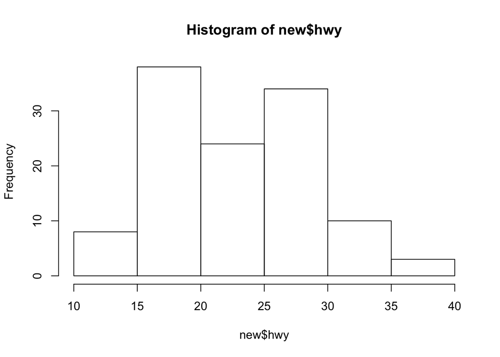

```r
hist(new$hwy)
```

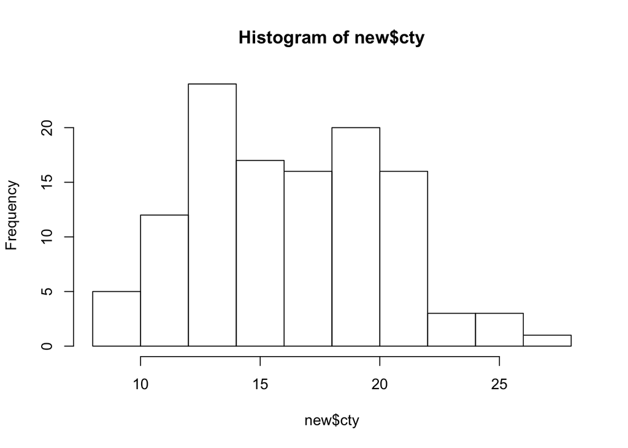

```r
hist(new$cty)
```

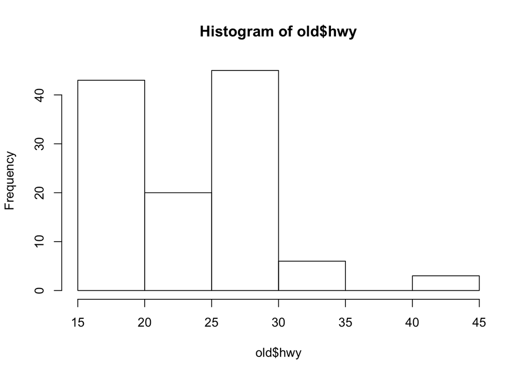

```r
meanNewHwy <- sum(new$hwy)/length(new$hwy)
meanNewCty <- sum(new$cty)/length(new$cty)

hist(old$hwy)
```

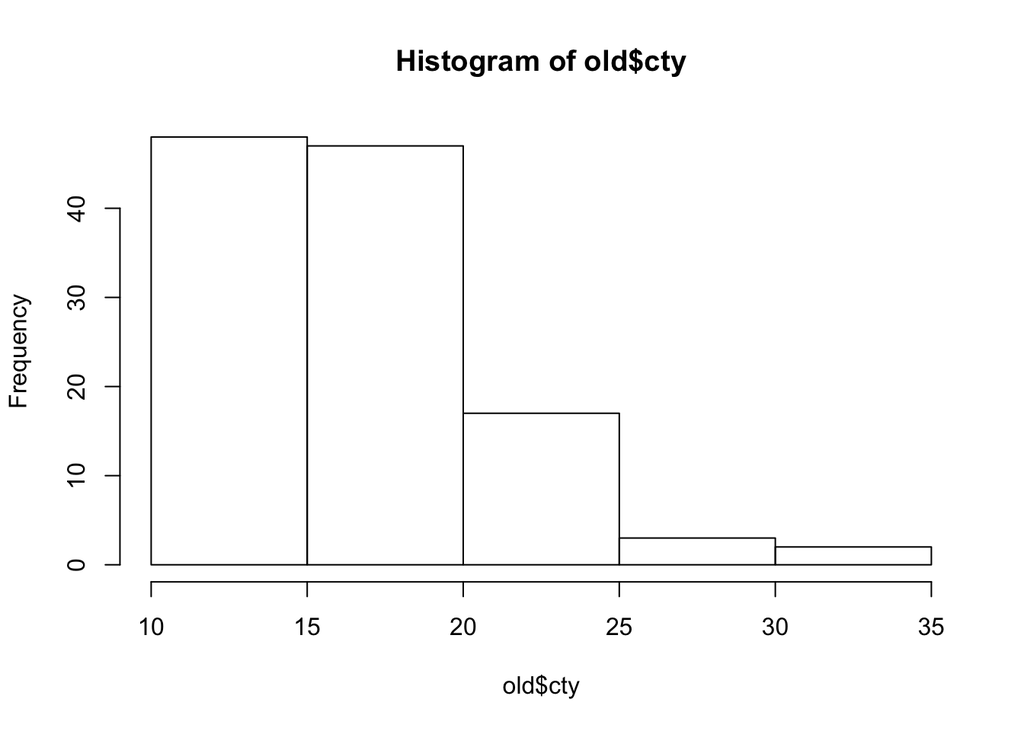

```r
hist(old$cty)
```

```r
meanoldHwy <- sum(old$hwy)/length(old$hwy)
meanoldCty <- sum(old$cty)/length(old$cty)

meanNewHwy
```

```
## [1] 23.45299
```

```r
meanNewCty
```

```
## [1] 16.70085
```

```r
meanoldHwy
```

```
## [1] 23.42735
```

```r
meanoldCty
```

```
## [1] 17.01709
```

```r
var(new$hwy)
```

```
## [1] 34.1982
```

```r
var(new$cty)
```

```
## [1] 16.45284
```

```r
var(old$hwy)
```

```
## [1] 37.02269
```

```r
var(old$cty)
```

```
## [1] 19.87902
```

##### Analysis:

Quite shockingly, the differency in both highway and city fuel efficiencies for cars had not changed much between 1999 and 2008. At first glance, the histograms for the old cars seem right skewed which would imply that their mean is lower than the much more well centered 2008 data, but after calculating the true mean for each new/old and hwy/cty efficiency we see that there is very little difference between new and old. Calculating the variance of the new and old across the two categories did reveal a reduction in variance across the categories for the 2008 models. This could suggest that some of the worst performing vehicles were improved, but also could mean that there were fewer cars analyzed with outstandingly high feul efficiency.